# bootstrapping

Quinn Anderson

2023-11-09

## simulate data

```r
n_samp = 250

sim_df_const =
  tibble(
    x = rnorm(n_samp, 1, 1),
    error = rnorm(n_samp, 0, 1),
    y = 2 + 3 * x + error)

sim_df_nonconst = sim_df_const |>
  mutate(
  error = error * .75 * x,
  y = 2 + 3 * x + error)
```

Plot the datasets:

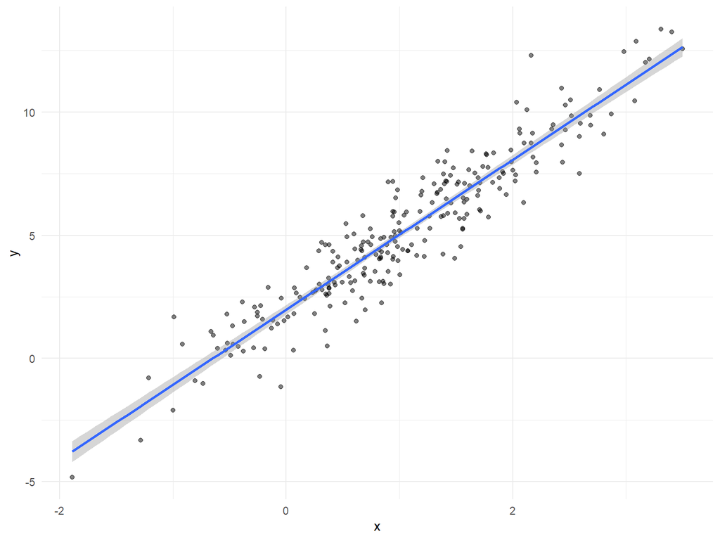

```r
sim_df_const |>
  ggplot(aes(x = x, y = y)) +
  geom_point(alpha = .5) +
  stat_smooth(method = "lm")
```

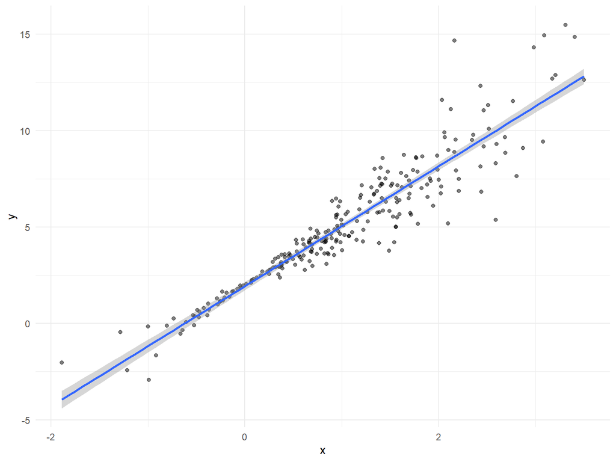

```r
sim_df_nonconst |>
  ggplot(aes(x = x, y = y)) +
  geom_point(alpha = .5) +
  stat_smooth(method = "lm")
```

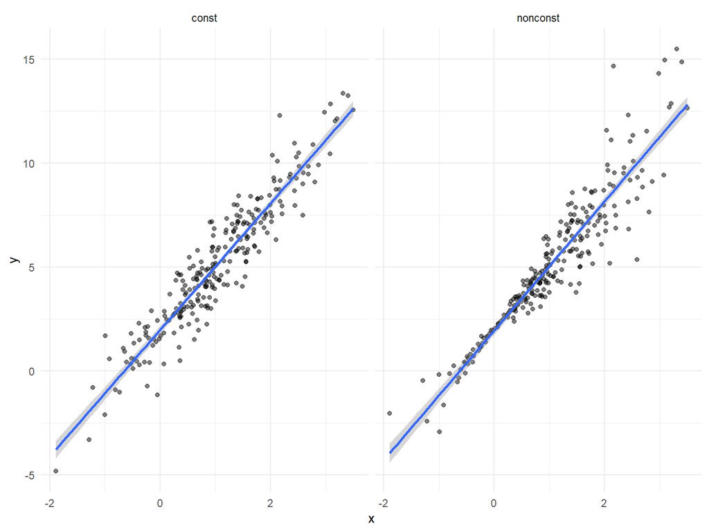

```r
sim_df =
  bind_rows(const = sim_df_const, nonconst = sim_df_nonconst, .id = "data_source")

sim_df |>
  ggplot(aes(x = x, y = y)) +
  geom_point(alpha = .5) +
  stat_smooth(method = "lm") +
  facet_grid(~data_source)
```

Now, let’s fit simple linear regressions to both datasets.

```r
lm(y ~ x, data = sim_df_const) |> broom::tidy() |> knitr::kable(digits = 3)
```

| term | estimate | std.error | statistic | p.value |
| --- | --- | --- | --- | --- |
| (Intercept) | 1.977 | 0.098 | 20.157 | 0 |
| x | 3.045 | 0.070 | 43.537 | 0 |

```r
lm(y ~ x, data = sim_df_nonconst) |> broom::tidy() |> knitr::kable(digits = 3)
```

| term | estimate | std.error | statistic | p.value |
| --- | --- | --- | --- | --- |
| (Intercept) | 1.934 | 0.105 | 18.456 | 0 |
| x | 3.112 | 0.075 | 41.661 | 0 |

the way we solve this is by using the bootstrap. the usual assumptions are not met in this data set. in this case, we’ll need to understand what the distribution of the intercept and slope are going to be under repeated sampling. we’ll get that distribution using a bootstrap.

## draw one bootstrap sample

```r
boot_sample = function(df) {

  sample_frac(df, replace = TRUE) |>
    arrange(x)

}
```

check if this works…

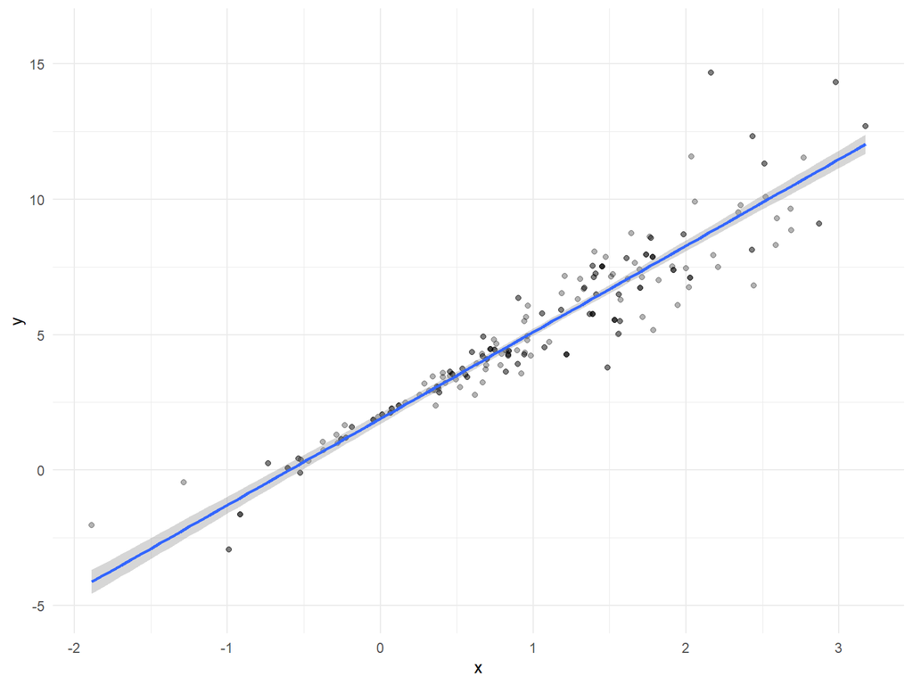

```r
boot_sample(sim_df_nonconst) |>
  ggplot(aes(x = x, y = y)) +
  geom_point(alpha = 0.3) +
  stat_smooth(method = "lm") +
  ylim(-5, 16)
```

## drawing many bootstrap samples

```r
boot_straps =
  tibble(strap_number = 1:1000,
         strap_sample = rerun(1000, boot_sample(sim_df_nonconst))
    )
```

check to see if this has worked…

```r
boot_straps |>
  slice(1:3) |>
  mutate(strap_sample = map(strap_sample, arrange, x)) |>
  pull(strap_sample)
```

```
## [[1]]
## # A tibble: 250 × 3
##         x   error       y
##     <dbl>   <dbl>   <dbl>
##  1 -1.89   1.62   -2.04
##  2 -1.89   1.62   -2.04
##  3 -1.21  -0.781  -2.43
##  4 -1.21  -0.781  -2.43
##  5 -1.00   0.832  -0.169
##  6 -0.989 -1.97   -2.93
##  7 -0.914 -0.908  -1.65
##  8 -0.606 -0.106   0.0774
##  9 -0.536  0.0227  0.413
## 10 -0.524 -0.536  -0.106
## # ℹ 240 more rows
##
## [[2]]
## # A tibble: 250 × 3
##         x  error       y
##     <dbl>  <dbl>   <dbl>
##  1 -1.29   1.40  -0.454
##  2 -0.989 -1.97  -2.93
##  3 -0.914 -0.908 -1.65
##  4 -0.914 -0.908 -1.65
##  5 -0.805  0.292 -0.123
##  6 -0.805  0.292 -0.123
##  7 -0.665 -0.544 -0.539
##  8 -0.641 -0.416 -0.338
##  9 -0.606 -0.106  0.0774
## 10 -0.606 -0.106  0.0774
## # ℹ 240 more rows
##
## [[3]]
## # A tibble: 250 × 3
##         x  error      y
##     <dbl>  <dbl>  <dbl>
##  1 -1.89   1.62  -2.04
##  2 -1.89   1.62  -2.04
##  3 -1.29   1.40  -0.454
##  4 -1.29   1.40  -0.454
##  5 -1.00   0.832 -0.169
##  6 -0.914 -0.908 -1.65
##  7 -0.805  0.292 -0.123
##  8 -0.665 -0.544 -0.539
##  9 -0.665 -0.544 -0.539
## 10 -0.665 -0.544 -0.539
## # ℹ 240 more rows
```

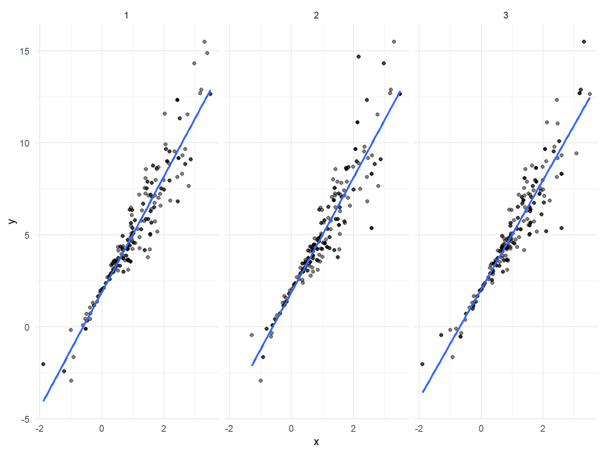

```r
boot_straps |>
  slice(1:3) |>
  unnest(strap_sample) |>
  ggplot(aes(x = x, y = y)) +
  geom_point(alpha = .5) +
  stat_smooth(method = "lm", se = FALSE) +
  facet_grid(~strap_number)
```

great! now, can I run my analysis on these…?

```r
boot_results =
  boot_straps |>
  mutate(
    models = map(.x = strap_sample, ~lm(y ~ x, data = .x)),
    results = map(models, broom::tidy)) |>
  select(strap_number, results) |>
  unnest(results)
```

what do I have now? let’s look at the estimate of the sd under bootstrapping samples. what is the actual sd of the estimate under repeated sampling?

```r
boot_results |>
  group_by(term) |>
  summarize(
    mean_est = mean(estimate),
    sd_est = sd(estimate))
```

```
## # A tibble: 2 × 3
##   term        mean_est sd_est
##   <chr>          <dbl>  <dbl>
## 1 (Intercept)     1.93 0.0747
## 2 x               3.11 0.101
```

let’s look at the distributions

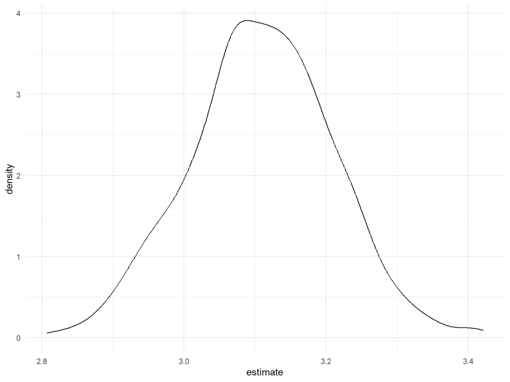

```r
boot_results |>
  filter(term == "x") |>
  ggplot(aes(x = estimate)) +
  geom_density()
```

construct bootstrap CI

```r
boot_results |>
  group_by(term) |>
  summarize(
    ci_lower = quantile(estimate, 0.025),
    ci_upper = quantile(estimate, 0.975))
```

```
## # A tibble: 2 × 3
##   term        ci_lower ci_upper
##   <chr>          <dbl>    <dbl>
## 1 (Intercept)     1.79     2.08
## 2 x               2.91     3.31
```

## bootstrap using modelr

can we simplify anything?

```r
sim_df_nonconst |>
  bootstrap(1000, id = "strap_number") |>
  mutate(
    models = map(.x = strap, ~lm(y ~ x, data = .x)),
    results = map(models, broom::tidy)) |>
  select(strap_number, results) |>
  unnest(results) |>
  group_by(term) |>
  summarize(
    mean_est = mean(estimate),
    sd_est = sd(estimate))
```

```
## # A tibble: 2 × 3
##   term        mean_est sd_est
##   <chr>          <dbl>  <dbl>
## 1 (Intercept)     1.93 0.0762
## 2 x               3.11 0.104
```

check with a dataset where the assumptions are met. if your assumptions are true, you can do usual linear model stuff, but you can also do the bootstrapping procedure.

```r
sim_df_const |>
  bootstrap(1000, id = "strap_number") |>
  mutate(
    models = map(.x = strap, ~lm(y ~ x, data = .x)),
    results = map(models, broom::tidy)) |>
  select(strap_number, results) |>
  unnest(results) |>
  group_by(term) |>
  summarize(
    mean_est = mean(estimate),
    sd_est = sd(estimate))
```

```
## # A tibble: 2 × 3
##   term        mean_est sd_est
##   <chr>          <dbl>  <dbl>
## 1 (Intercept)     1.98 0.0985
## 2 x               3.04 0.0697
```

## revisit NYC airbnb data!!!!

import, clean, tidy data set:

```r
data("nyc_airbnb")

nyc_airbnb =
  nyc_airbnb |>
  mutate(stars = review_scores_location / 2) |>
  rename(
    borough = neighbourhood_group,
    neighborhood = neighbourhood) |>
  filter(borough != "Staten Island") |>
  select(price, stars, borough, neighborhood, room_type)
```

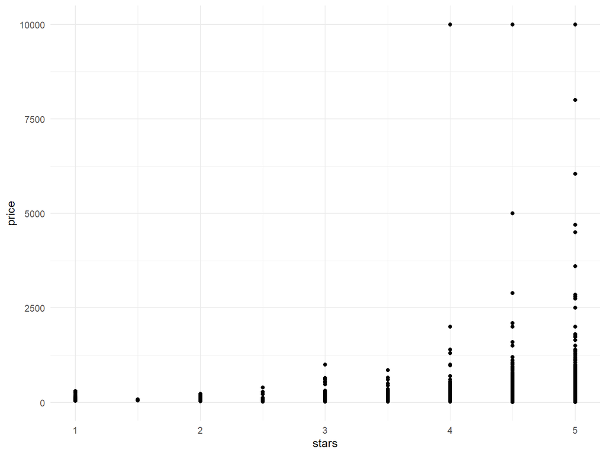

```r
nyc_airbnb |>
  ggplot(aes(x = stars, y = price)) +
  geom_point()
```

```r
airbnb_boot_results =
  nyc_airbnb |>
  filter(borough == "Manhattan") |>
  drop_na(stars) |>
  bootstrap(1000, id = "strap_number") |>
  mutate(
    models = map(.x = strap, ~lm(price ~ stars, data = .x)),
    results = map(models, broom::tidy)) |>
  select(strap_number, results) |>
  unnest(results)

airbnb_boot_results |>
  group_by(term) |>
  summarize(
    mean_est = mean(estimate),
    sd_est = sd(estimate))
```

```
## # A tibble: 2 × 3
##   term        mean_est sd_est
##   <chr>          <dbl>  <dbl>
## 1 (Intercept)    -35.0  31.6
## 2 stars           43.4   6.41
```

compare this to `lm`

```r
nyc_airbnb |>
  filter(borough == "Manhattan") |>
  drop_na(stars) |>
  lm(price ~ stars, data = .) |>
  broom::tidy()
```

[output not shown]

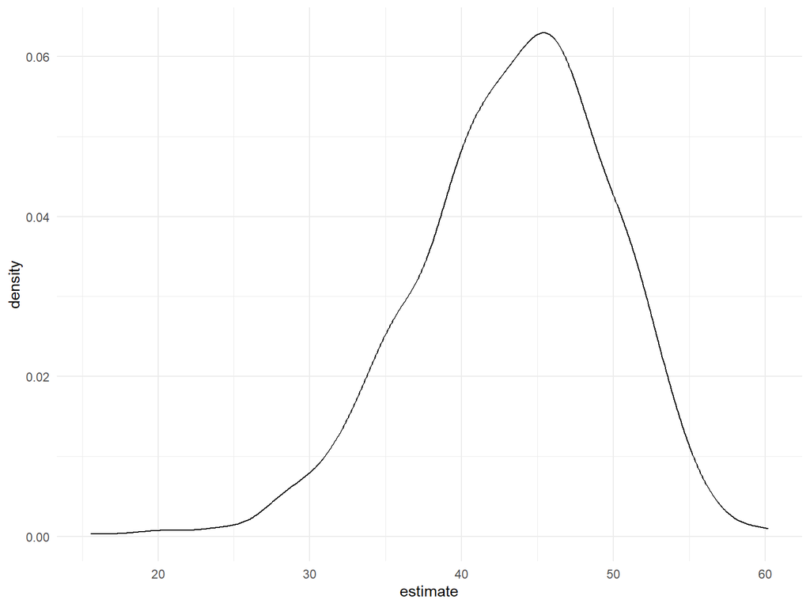

```r
airbnb_boot_results |>
  filter(term == "stars") |>
  ggplot(aes(x = estimate)) +
  geom_density()
```